# MLM analysis for P2

Hannah

11/20/2018

*Redone with new set of 11 electrodes. Reblocked participants who were missing trials and increased number of rejected electrodes.*

## 1. Gender categorization task

Median number of trials per condition per participant: 26  
Min:11  
Max:32

### 1a. P2 waveforms

See figures in “4 Grand averages/Plots”.

### 1b. Effects of Target Race, Target Gender, Fixation, and Participant Race on P2 amplitude (all trials)

DV is trial level data. Subjects with < 50% trials accepted are excluded.  
Electrodes: CZ, CPZ, PZ, C1, C2, C3, C4, CP1, CP2, CP3, CP4

P2 is quantified as mean amplitude from 130-190 ms.

Participant race, target race, and target gender are effect coded. Both eye and forehead fixation trials are included.

Included n = 63 (32 black, 31 white)

```
## lme4::lmer(formula = value ~ TarRace.e * TarGender.e * Fix.e *
##     ParRace.e + (TarRace.e + TarGender.e | Subject) + (1 | Electrode),
##     data = gendat)
```

```
##  Groups    Name        Std.Dev. Corr
##  Subject   (Intercept) 2.67101
##            TarRace.e   0.44849   0.060
##            TarGender.e 0.54911   0.025 -0.047
##  Electrode (Intercept) 0.82332
##  Residual              8.17286
```

|  | Estimate | Std. Error | df | t value | Pr(>\|t\|) |
| --- | --- | --- | --- | --- | --- |
| (Intercept) | 2.913 | 0.419 | 51.440 | 6.956 | 0.000 |
| TarRace.e | -0.217 | 0.061 | 61.269 | -3.574 | 0.001 |
| TarGender.e | 0.188 | 0.073 | 59.904 | 2.586 | 0.012 |
| Fix.e | -0.299 | 0.022 | 137278.801 | -13.559 | 0.000 |
| ParRace.e | 0.928 | 0.337 | 61.004 | 2.752 | 0.008 |
| TarRace.e:TarGender.e | 0.032 | 0.022 | 137297.768 | 1.436 | 0.151 |
| TarRace.e:Fix.e | 0.069 | 0.022 | 137268.444 | 3.117 | 0.002 |
| TarGender.e:Fix.e | 0.002 | 0.022 | 137269.404 | 0.076 | 0.939 |
| TarRace.e:ParRace.e | -0.089 | 0.061 | 61.269 | -1.472 | 0.146 |
| TarGender.e:ParRace.e | 0.085 | 0.073 | 59.904 | 1.171 | 0.246 |
| Fix.e:ParRace.e | -0.091 | 0.022 | 137278.801 | -4.132 | 0.000 |
| TarRace.e:TarGender.e:Fix.e | -0.076 | 0.022 | 137279.541 | -3.445 | 0.001 |
| TarRace.e:TarGender.e:ParRace.e | -0.006 | 0.022 | 137297.768 | -0.281 | 0.779 |
| TarRace.e:Fix.e:ParRace.e | -0.064 | 0.022 | 137268.444 | -2.900 | 0.004 |
| TarGender.e:Fix.e:ParRace.e | 0.019 | 0.022 | 137269.404 | 0.838 | 0.402 |
| TarRace.e:TarGender.e:Fix.e:ParRace.e | -0.021 | 0.022 | 137279.541 | -0.973 | 0.330 |

### 1c. Just Black participants

Fixation and target race are effect coded.

```
## lme4::lmer(formula = value ~ TarRace.e * Fix.e + (TarRace.e +
##     Fix.e | Subject) + (1 | Electrode), data = filter(gendat,
##     ParRace == "Black"))
```

```
##  Groups    Name        Std.Dev. Corr
##  Subject   (Intercept) 2.57334
##            TarRace.e   0.40058   0.018
##            Fix.e       0.58652  -0.272  0.093
##  Electrode (Intercept) 0.80738
##  Residual              7.77323
```

|  | Estimate | Std. Error | df | t value | Pr(>\|t\|) |
| --- | --- | --- | --- | --- | --- |
| (Intercept) | 1.977 | 0.517 | 40.614 | 3.825 | 0.000 |
| TarRace.e | -0.139 | 0.077 | 30.955 | -1.809 | 0.080 |
| Fix.e | -0.214 | 0.108 | 31.054 | -1.977 | 0.057 |
| TarRace.e:Fix.e | 0.134 | 0.030 | 67360.833 | 4.456 | 0.000 |

### 1d. Just White participants

Fixation and target race are effect coded.

```
## lme4::lmer(formula = value ~ TarRace.e * Fix.e + (TarRace.e +
##     Fix.e | Subject) + (1 | Electrode), data = filter(gendat,
##     ParRace == "White"))
```

```
##  Groups    Name        Std.Dev. Corr
##  Subject   (Intercept) 2.76967
##            TarRace.e   0.49759   0.096
##            Fix.e       0.86214  -0.159  0.008
##  Electrode (Intercept) 0.83630
##  Residual              8.52017
```

|  | Estimate | Std. Error | df | t value | Pr(>\|t\|) |
| --- | --- | --- | --- | --- | --- |
| (Intercept) | 3.845 | 0.559 | 39.338 | 6.883 | 0.000 |
| TarRace.e | -0.297 | 0.095 | 30.130 | -3.124 | 0.004 |
| Fix.e | -0.408 | 0.158 | 29.568 | -2.580 | 0.015 |
| TarRace.e:Fix.e | -0.003 | 0.032 | 69905.603 | -0.091 | 0.927 |

### 1e. Plot for interactions

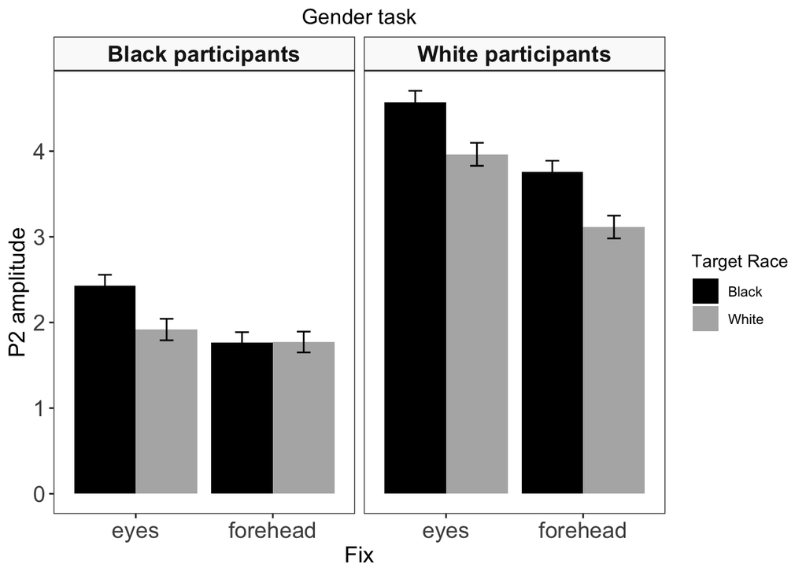

## 2. Race categorization task

Median number of trials per condition per participant: 27  
Min:10  
Max:32

### 2a. P2 waveforms

See figures in “4 Grand averages/Plots”.

### 2b. Effects of Target Race, Target Gender, and Participant Race on P2 amplitude (all trials)

DV is trial level data. Subjects with < 50% trials accepted are excluded.  
Electrodes: CZ, CPZ, PZ, C1, C2, C3, C4, CP1, CP2, CP3, CP4

P2 is quantified as mean amplitude from 130-190 ms.

Participant race, target race, and target gender are effect coded. Both eye and forehead fixation trials are included.

Included n = 63 (33 black, 30 white)

All variables are effect coded.

```
## lme4::lmer(formula = value ~ TarRace.e * TarGender.e * Fix.e *
##     ParRace.e + (TarRace.e + TarGender.e | Subject) + (1 | Electrode),
##     data = racedat)
```

```
##  Groups    Name        Std.Dev. Corr
##  Subject   (Intercept) 2.80954
##            TarRace.e   0.64188  -0.131
##            TarGender.e 0.51395  -0.127  0.037
##  Electrode (Intercept) 0.80763
##  Residual              8.13568
```

|  | Estimate | Std. Error | df | t value | Pr(>\|t\|) |
| --- | --- | --- | --- | --- | --- |
| (Intercept) | 2.842 | 0.431 | 55.627 | 6.601 | 0.000 |
| TarRace.e | -0.279 | 0.084 | 60.410 | -3.326 | 0.002 |
| TarGender.e | 0.113 | 0.068 | 60.519 | 1.652 | 0.104 |
| Fix.e | -0.323 | 0.022 | 142654.269 | -14.997 | 0.000 |
| ParRace.e | 0.799 | 0.355 | 61.011 | 2.251 | 0.028 |
| TarRace.e:TarGender.e | -0.080 | 0.022 | 142645.441 | -3.722 | 0.000 |
| TarRace.e:Fix.e | 0.124 | 0.022 | 142631.801 | 5.764 | 0.000 |
| TarGender.e:Fix.e | -0.010 | 0.022 | 142635.421 | -0.481 | 0.631 |
| TarRace.e:ParRace.e | 0.008 | 0.084 | 60.410 | 0.097 | 0.923 |
| TarGender.e:ParRace.e | 0.006 | 0.068 | 60.519 | 0.091 | 0.928 |
| Fix.e:ParRace.e | -0.016 | 0.022 | 142654.269 | -0.757 | 0.449 |
| TarRace.e:TarGender.e:Fix.e | 0.149 | 0.022 | 142651.091 | 6.896 | 0.000 |
| TarRace.e:TarGender.e:ParRace.e | -0.020 | 0.022 | 142645.441 | -0.911 | 0.362 |
| TarRace.e:Fix.e:ParRace.e | 0.058 | 0.022 | 142631.801 | 2.677 | 0.007 |
| TarGender.e:Fix.e:ParRace.e | 0.036 | 0.022 | 142635.421 | 1.690 | 0.091 |
| TarRace.e:TarGender.e:Fix.e:ParRace.e | -0.042 | 0.022 | 142651.091 | -1.944 | 0.052 |

### 2c. Just Black participants

Fixation and target race are effect coded.

```
## lme4::lmer(formula = value ~ TarRace.e * Fix.e + (TarRace.e +
##     Fix.e | Subject) + (1 | Electrode), data = filter(racedat,
##     ParRace == "Black"))
```

```
##  Groups    Name        Std.Dev. Corr
##  Subject   (Intercept) 2.98245
##            TarRace.e   0.57215  -0.112
##            Fix.e       0.57406   0.047  0.580
##  Electrode (Intercept) 0.80398
##  Residual              7.73781
```

|  | Estimate | Std. Error | df | t value | Pr(>\|t\|) |
| --- | --- | --- | --- | --- | --- |
| (Intercept) | 2.050 | 0.574 | 41.031 | 3.573 | 0.001 |
| TarRace.e | -0.294 | 0.104 | 31.599 | -2.829 | 0.008 |
| Fix.e | -0.334 | 0.104 | 32.028 | -3.208 | 0.003 |
| TarRace.e:Fix.e | 0.071 | 0.029 | 71793.216 | 2.472 | 0.013 |

### 2d. Just White participants

Fixation and target race are effect coded.

```
## lme4::lmer(formula = value ~ TarRace.e * Fix.e + (TarRace.e +
##     Fix.e | Subject) + (1 | Electrode), data = filter(racedat,
##     ParRace == "White"))
```

```
##  Groups    Name        Std.Dev. Corr
##  Subject   (Intercept) 2.59682
##            TarRace.e   0.70802  -0.161
##            Fix.e       0.64925  -0.252 -0.162
##  Electrode (Intercept) 0.81243
##  Residual              8.51134
```

|  | Estimate | Std. Error | df | t value | Pr(>\|t\|) |
| --- | --- | --- | --- | --- | --- |
| (Intercept) | 3.646 | 0.535 | 38.350 | 6.819 | 0.000 |
| TarRace.e | -0.281 | 0.133 | 28.764 | -2.105 | 0.044 |
| Fix.e | -0.321 | 0.123 | 28.858 | -2.611 | 0.014 |
| TarRace.e:Fix.e | 0.194 | 0.032 | 70852.916 | 6.071 | 0.000 |

### 1e. Plot for interactions

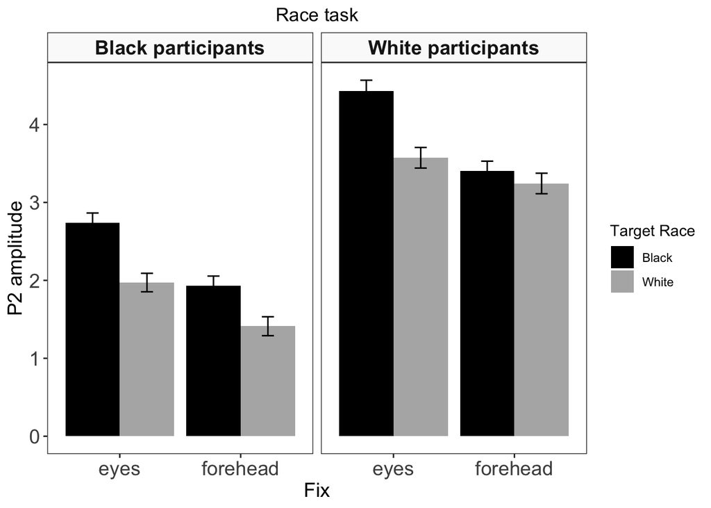

## 3. Comparison of tasks

DV is trial level data. Subjects with < 50% trials accepted are excluded.

Included n = 65 (34 black, 31 white)

#### Testing difference in effect of RACE and GENDER across tasks, collapsing across participant race:

Target Race, Target Gender, and Task are included as effect-coded predictors. Only the Target Race x Task and Target Gender x Task interactions are included. Both eye and forehead fixation trials are included.

```
## lme4::lmer(formula = value ~ TarGender.e * Task.e + TarRace.e *
##     Task.e + (TarGender.e + TarRace.e + Task.e | Subject) + (1 |
##     Electrode), data = dat)
```

```
##  Groups    Name        Std.Dev. Corr
##  Subject   (Intercept) 2.72626
##            TarGender.e 0.38579  -0.031
##            TarRace.e   0.44491  -0.105  0.154
##            Task.e      0.78994   0.068 -0.166 -0.020
##  Electrode (Intercept) 0.81685
##  Residual              8.17600
```

|  | Estimate | Std. Error | df | t value | Pr(>\|t\|) |
| --- | --- | --- | --- | --- | --- |
| (Intercept) | 2.876 | 0.419 | 53.582 | 6.859 | 0.000 |
| TarGender.e | 0.145 | 0.050 | 62.784 | 2.879 | 0.005 |
| Task.e | -0.026 | 0.102 | 61.248 | -0.253 | 0.801 |
| TarRace.e | -0.253 | 0.057 | 63.185 | -4.411 | 0.000 |
| TarGender.e:Task.e | -0.034 | 0.016 | 254986.172 | -2.167 | 0.030 |
| Task.e:TarRace.e | -0.019 | 0.016 | 263196.280 | -1.205 | 0.228 |